# Log Likelihood Test For Text

## Background

단어 사이에 association을 측정하는 방법은 매우 여러가지이다. Pecina는 선행 연구들에서 제안된 방법 82가지를 제시하기도 하였다. [(Pecina, 2010)](https://link.springer.com/article/10.1007/s10579-009-9101-4)

## Association measures

현재 상태에서 어떤 방법을 사용할 것인가에 대해 답을 가지고 있지는 않다. 하지만 몇가지 기준은 생각하고 있다.

첫째, 통계적 가정이 필요로 하지 않는 방법일 것. 보통 통계적인 방법들은 정규성이라든지 등분산이라든지 사용되는 확률모델에 따라 전제가 요구된다. 하지만 빈도를 기반으로 한 텍스트 데이터는 이런 전제를 만족시키기 어렵다. 현재 collocation 분야에서 사용되는 방법 가운데 z-score와 같이 통계학에서 출발한 방법들은 rank를 비교하기 위한 수단으로만 사용되고 그 값에 통계적인 의미를 부여하지는 않는 방법으로 이 문제를 피하고 있다. 하지만 전제가 필요 없는 방법이 더 좋을 것이다.

둘째, 계산 방법이 비교적 단순하고 경제적일 것. bigram을 기준으로 2x2 contigency table에서 가장 정확한 방법은 Fisher’s exact test라고 할 수 있다. 하지만 계산 방법이 복잡하고 부하가 많은 펙토리얼 연산을 수행해야만 한다. 따라서 대량에 데이터에 적용하기는 어렵다. 보다 경제적인 계산 방법이 필요하다.

셋째, 계산 결과가 직관적으로 어떤 의미를 가지는지 이해 될 것. 도출된 숫자가 단순히 상호 비교를 위한 rank라고 한다면 의미가 반감된다. 그 수치가 어떤 의미를 가지는지 직관적으로 이해할 수 있다면 더 좋을 것다.

넷째, 전체 텍스트 크기에 무관한 방법일 것. 즉 관찰빈도를 정규화 하지 않아도 되는 방법이면 더 좋겠다. [chi-squared value의 경우 sample size의 크기에 따라 결과값이 크게 영향을 받는다](http://rpubs.com/pinedance/296129). 따라서 동일한 sample에서 계산된 rank 값은 서로 비교 가능하지만, 서로 다른 sample에서 나온 값은 그대로 비교할 수 없다. 관찰빈도를 그대로 쓸 수 없고 sample size를 서로 같게 맞추어 상대빈도를 구하는 등 정규화가 필요하다. 이러한 정규화는 텍스트 데이터를 다룰 때 자주 발생하는 문제이다. ( cosine similarity가 많이 쓰이는 이유도 이런 정규화 문제 때문이다. )

## Log likelihood ratio

이런 기준을 가지고 고려하고 있는 방법 가운데 `log likelihood ratio`이 있다. 이 방법에 대해서는 사실 깊이 알지는 못한다. 다만 [Dunning이 제안](http://dl.acm.org/citation.cfm?id=972454)한 후로 Computational Linguistics 분야에서 종종 언급되고 있는 방법이다.

마침 그의 논문을 보다가 올려 놓은 데이터가 있어 궁금한 점이 있어 몇가지 테스트를 시도해 본다.

## Simulation using sample data

우선 논문에 실려 있는 데이터를 읽어들인다.

```r
bigram <- read.table("170803_log_likelihood_test_for_text_data.tsv", header=TRUE, sep="\t", quote=NULL, row.names=NULL)

# 논문에 이미 계산된 Log likelihood ratio 값 제거
bigram <- bigram[,c(2:5)]

# 관찰빈도
head(bigram)
```

```
##   o11  o10  o01   o00
## 1 110 2442  111 29114
## 2  29   13  123 31612
## 3  31   23  139 31584
## 4  10    0    3 31764
## 5  76  104 2476 29121
## 6  16   16   51 31694
```

sample size(n)이라든지, 기대빈도 등 부가정보들을 해당 데이터로부터 만든다.

```r
matrix_with_smooth <- function( vec ){

  matrix(vec, 2) + 0.25  # + 0.25 : smoothing

}

n <- sum( bigram[1,] )

e.bigram <- apply( bigram, 1, function(vec){ as.vector( chisq.test( matrix_with_smooth(vec) )$expected ) })

e.bigram <- as.data.frame( t(e.bigram) )

colnames(e.bigram) <- c("e11", "e10", "e01", "e00")

# 기대빈도
head(e.bigram)
```

```
##            e11        e10        e01      e00
## 1 17.791514570 2534.70849  203.70849 29021.79
## 2  0.203953993   42.29605  152.29605 31583.20
## 3  0.292411417   54.20759  170.20759 31553.29
## 4  0.004460633   10.49554   13.49554 31754.00
## 5 14.498277110  166.00172 2538.00172 29059.50
## 6  0.069033608   32.43097   67.43097 31678.07
```

log likelihood ratio를 구하는 공식을 함수로 만든다. 아울러 계산을 좀 더 단순화한 simple log likelihood 공식도 함수로 만들었다. 참고로 이 공식은 [Evert의 연구](https://goo.gl/QJTLxj)에서 보았다.

```r
loglikelihood <- function( vec ){

  o <- matrix_with_smooth(vec)
  e <- chisq.test(o)$expected
  ll <- -2 * sum( o * log( e / o) )
  round(ll, 2)

}


loglikelihood_simple <- function( vec ){

  o <- matrix_with_smooth(vec)
  e <- chisq.test(o)$expected
  ll.s <-  2 * ( o[1,1] * log( o[1,1] / e[1,1]) - o[1,1] + e[1,1] )
  round(ll.s, 2)

}


fisher.exact <- function( vec ){

  o <- matrix_with_smooth(vec)
  fisher.test(o)$p.value

}


chi_squared <- function( vec ){

  o <- matrix_with_smooth(vec)
  chisq.test(o)$statistic

}

chi_squared_test <- function( vec ){

  o <- matrix_with_smooth(vec)
  chisq.test(o)$p.value

}

phi_coefficient <- function( vec ){

  o <- matrix_with_smooth(vec)
  rs <- rowSums(o)
  cs <- colSums(o)
  ( ( o[1,1] * o[2,2] ) - ( o[1,2] * o[2,1]) ) / sqrt( rs[1] * rs[2] * cs[1] * cs[2] )

}
```

공식을 사용해 연산하였다.

```r
ll <- apply(bigram, 1, loglikelihood)
ll.sim <- apply(bigram, 1, loglikelihood_simple)
```

## Method 탐색

### log likelihood ratio vs simple log likelihood ratio

log likelihood ratio와 그것을 단순화한 `간단공식` 사이에는 어떤 관계가 있을까.

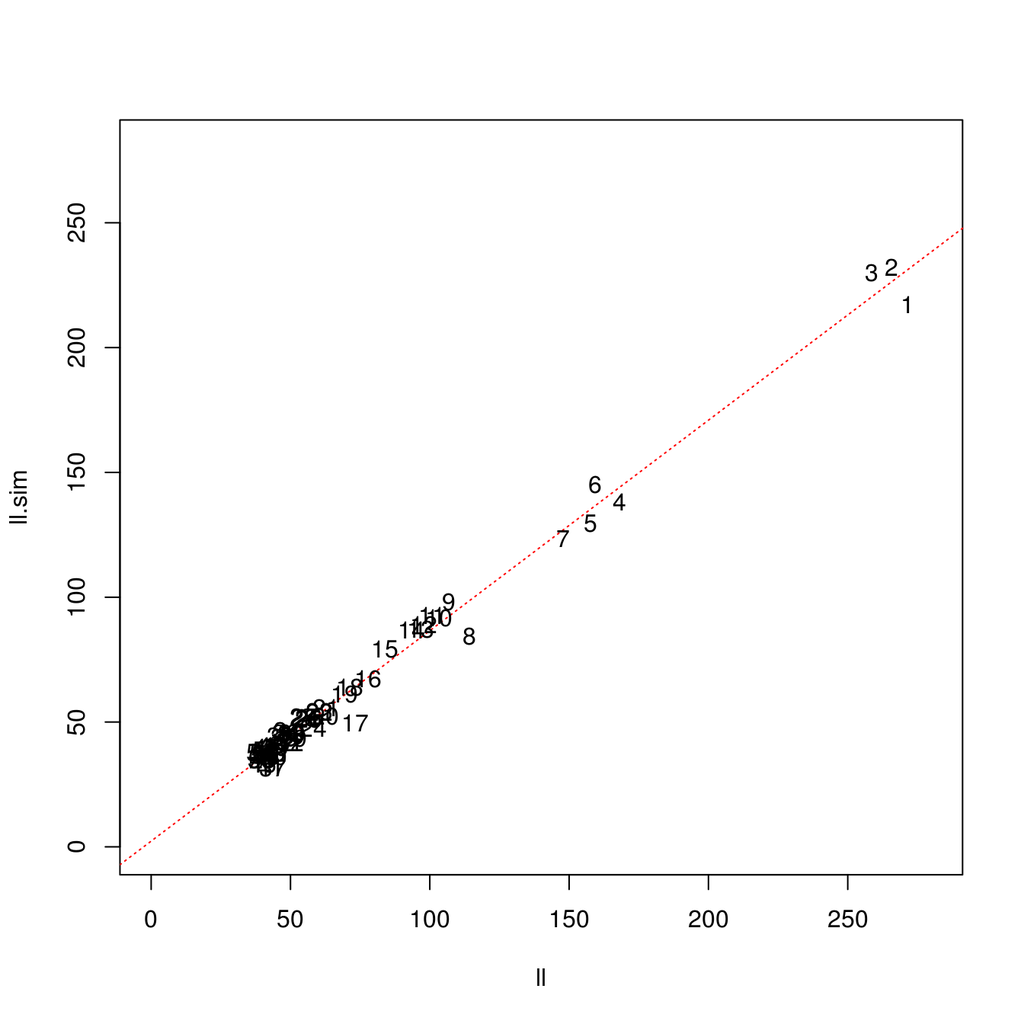

```r
plot(ll, ll.sim, xlim=c(0,280), ylim=c(0,280), type="n")
abline( lm(ll.sim~ll), col="red", lty="dotted" )
text( ll, ll.sim, labels=rownames(bigram))
```

상당히 높은 선형 관계를 보였다. 간단공식으로 대체할 수 있어 보인다. 다만 기울기가 0.84로 1보다 작다. 따라서 결과 값이 상대적으로 작게 측정된다.

### p value ( log likelihood ratio vs fisher exact test, chisq.test )

log likelihood ratio의 값은 chi 분포를 따르는 특성이 있다. 이를 통해 p.value를 도출한 다음 fisher와 비교해 보았다.

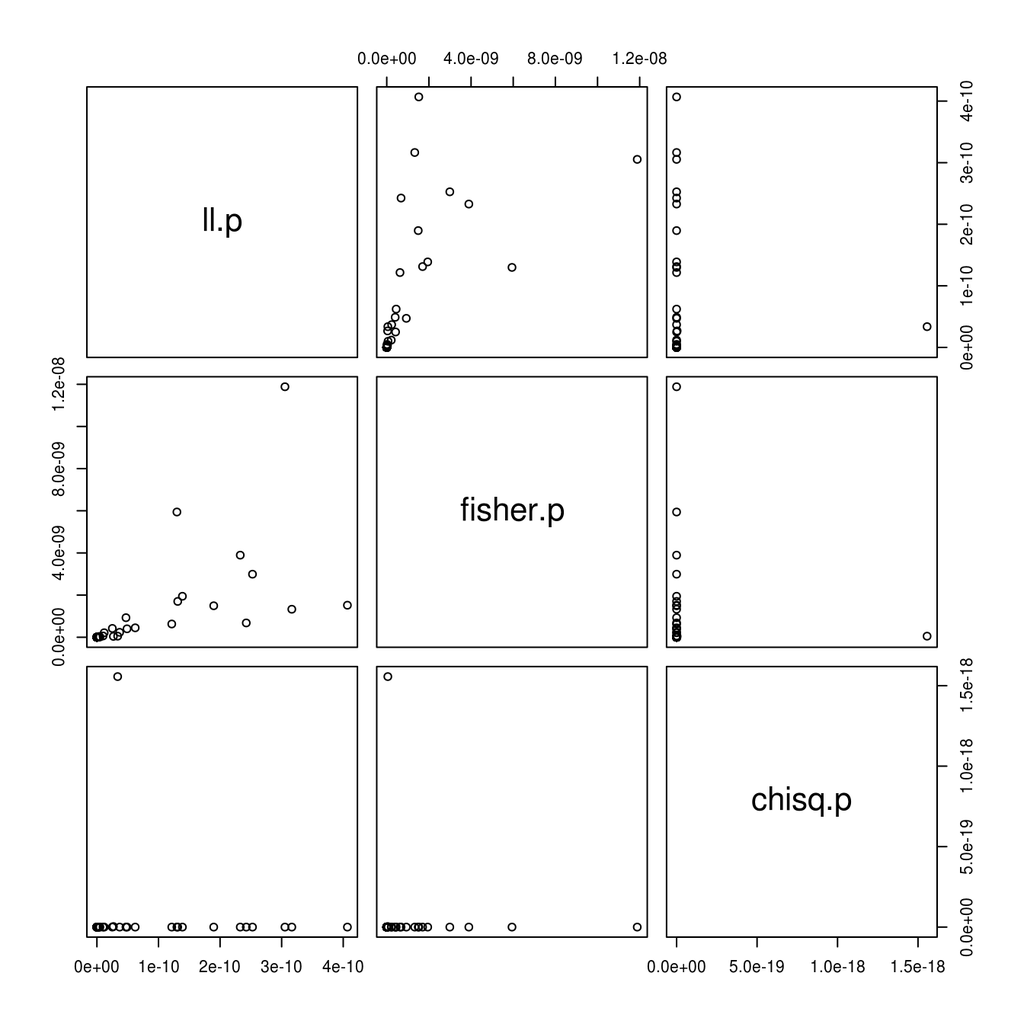

```r
fisher.p <- apply(bigram, 1, fisher.exact)
chisq.p <- apply(bigram, 1, chi_squared_test)
ll.p <- sapply( ll, function(x){ pchisq(x, df=1, lower.tail=FALSE) })

plot( data.frame(ll.p=ll.p, fisher.p=fisher.p, chisq.p=chisq.p ))
```

차이가 컸다.

역시 chisq.test p.value는 신뢰하기 어려웠다.

### association strength ( log likelihood ratio vs other method )

흥미롭게도 2개의 그룹으로 나누어졌다. 첫째 그룹은 ll, t.score, we.eudis으로 특히 t.score와 we.eduis는 상당히 유사한 경향을 보였다. 둘째 그룹은 chi.squared, z.score, mu.info으로 모두 유사한 경향을 보였다.

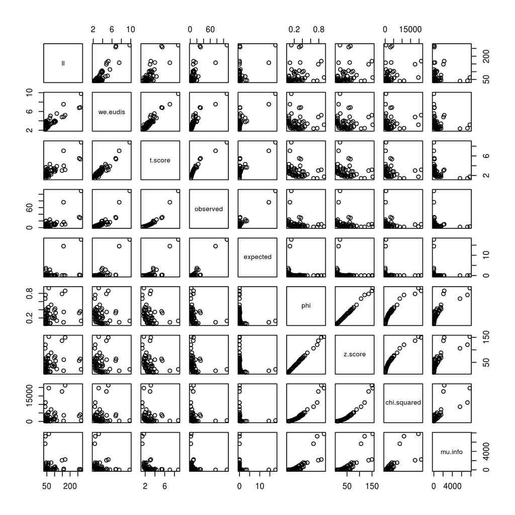

```r
# Chi Squared
chi.squared <- apply(bigram, 1, chi_squared)

# weighted Euclidean distance
we.eudis <- apply( (bigram - e.bigram)^2 / (bigram + e.bigram), 1, function(v){ sqrt( sum(v) ) })

# mutual information
mu.info <- bigram[,1] / e.bigram[,1]

# t-score
t.score <- ( bigram$o11 - e.bigram$e11 ) / sqrt( bigram$o11 )

# z-score
z.score <- ( bigram$o11 - e.bigram$e11 ) / sqrt( e.bigram$e11 )

# phi coefficient
phi <- apply(bigram, 1, phi_coefficient)

associations <- data.frame(
  ll=ll, we.eudis=we.eudis, t.score=t.score,
  observed=bigram$o11, expected=e.bigram$e11,
  phi=phi, z.score=z.score, chi.squared=chi.squared, mu.info=mu.info)

plot( associations )
```

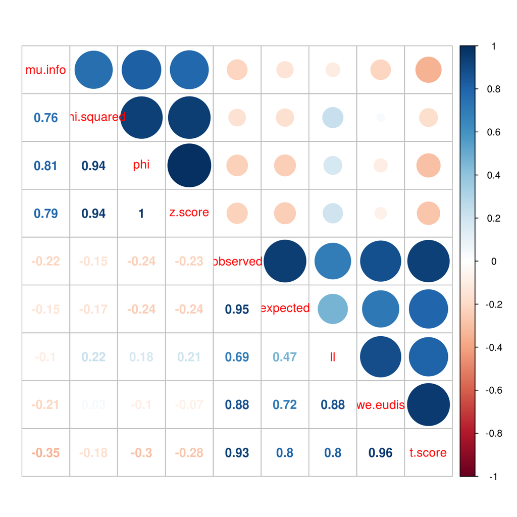

```r
library(corrplot)
cor_coeff <- cor( associations )
corrplot.mixed( cor_coeff, order ="hclust")
```

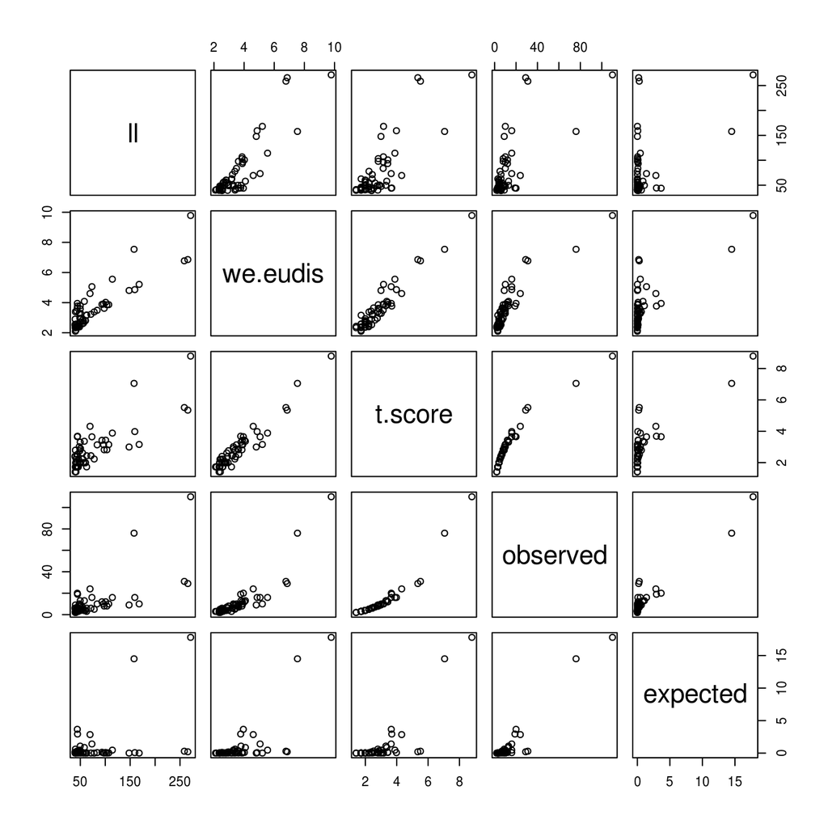

```r
# Group A
plot( associations[,c(1:5)] )
```

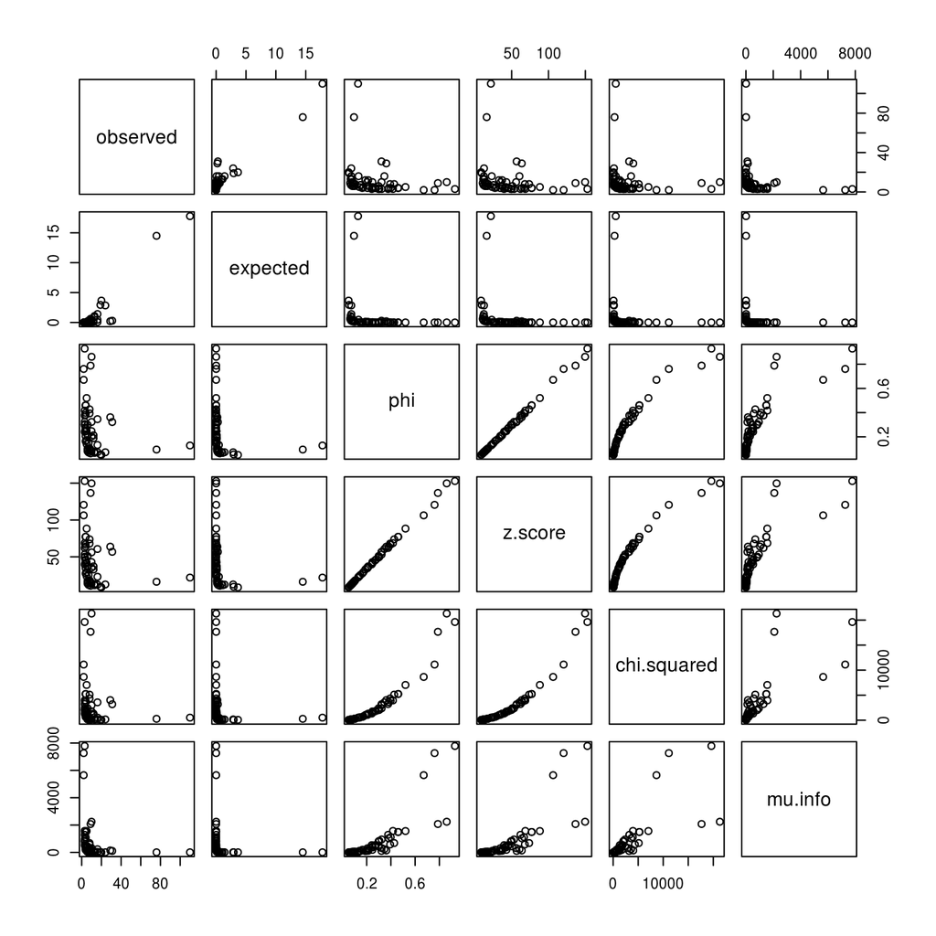

```r
# Group B
plot( associations[,c(4:9)] )
```

## data 탐색

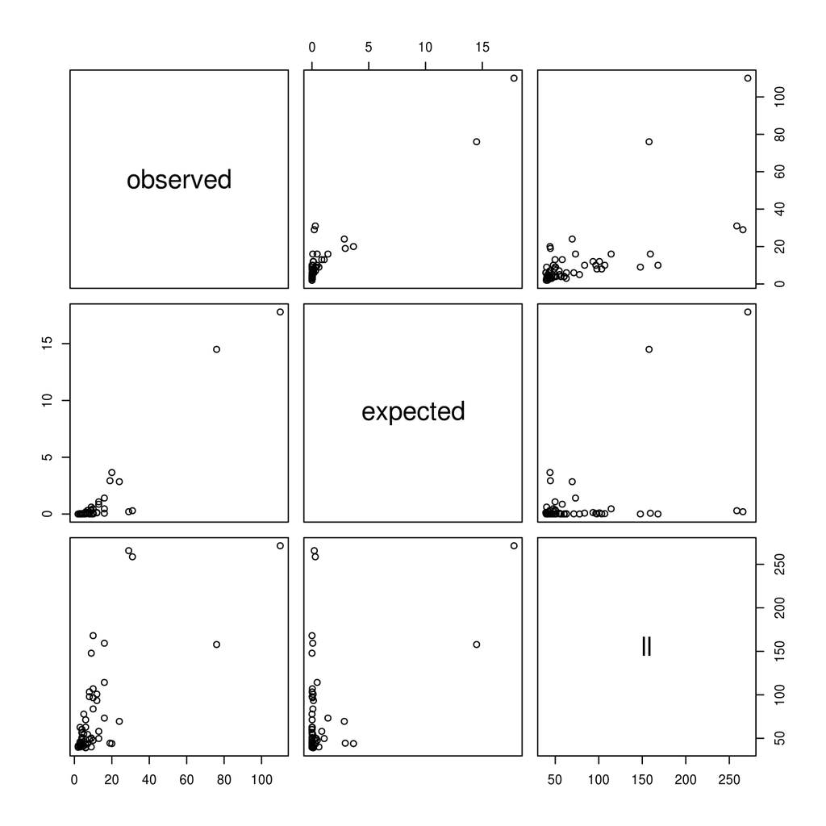

```r
plot( data.frame( observed=bigram$o11, expected=e.bigram$e11, ll=ll ) )
```

## Conclusion

도출 배경과 연산 방법이 다르지만 방법들 사이에 유사한 결과를 보이는 그룹이 있었다. ll, t.score, we.eudis 그릅과 phi, chi.squared, z.score, mu.info 그룹이다. 개인적으로 we.eudis를 상당히 신뢰하고 있 었기 때문에 전자의 방법들도 신뢰할 수 있을 것 같다.

mu.info는 관찰빈도가 작은 경우 지나치게 높게 평가되는 경향이 있다. 따라서 후자의 방법들은 모두 이러한 문제를 어느정도 가지고 있을 것 같다.

phi와 z.score는 완전히 같은 경향을 보였다. 하지만 phi가 -1에서 1까지의 경계를 가지고 있으므로 z.score보다 phi를 쓰는 편이 더 좋을 것 같다.

흥미롭게도 t.score와 z.score는 계산이 한 끝 차이인데, 상당히 다른 경향을 보였다.

이 가운데 몇가지를 선택해야 한다면 관찰빈도와 관련이 많은 것에서 없는 것 순으로

- t.score
- ll
- phi (~ z.score )
- mu.info (~ lift of association rule, df-idf)

이렇게 4가지를 선택 하고 싶다.

참고로 [A collection of English corpora](http://corpus.leeds.ac.uk/protected/query.html)에서는 mu.info, t.score, ll, Dice(여기서 다루지 않았다.) 이렇게 4가지 방법을 지원하고 있고, [웹 기반 코퍼스 분석 도구](http://corpus.korea.ac.kr/)에서는 t.score 1가지 방법을 지원하고 있다.

의견은 [이곳](https://github.com/pinedance/pinedance.github.io/issues)으로